# Лабораторная работа №3

Настройка прав доступа

Цыпин Дмитрий Алексеевич

1032253633@rudn.ru

Российский университет дружбы народов

2026-09-16

# Информация

## Докладчик

- Цыпин Дмитрий Алексеевич
- студент группы НПИбд-02-25
- ст. билет - 1032253633
- Российский университет дружбы народов им. П. Лумумбы
- 1032253633@rudn.ru

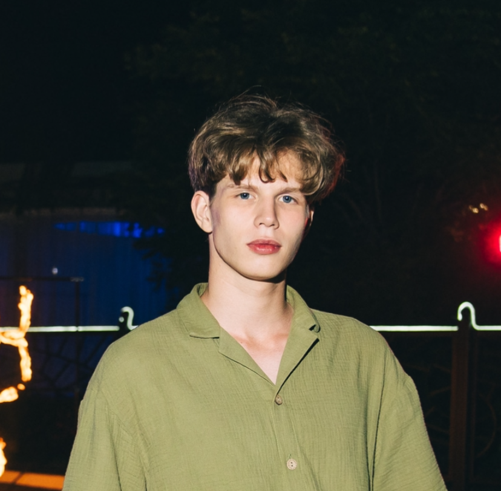

# Вводная часть

## Цель работы

Получение навыков настройки базовых и специальных прав доступа для групп пользователей в операционной системе типа Linux.

## Задание

1. Прочитайте справочное описание man по командам chgrp, chmod, getfacl, setfacl.
2. Выполните действия по управлению базовыми разрешениями для групп пользователей (раздел 3.3.1).
3. Выполните действия по управлению специальными разрешениями для групп пользователей (раздел 3.3.2).
4. Выполните действия по управлению расширенными разрешениями с использованием списков ACL для групп пользователей (раздел 3.3.3).

# Выполнение лабораторной работы

## Задание 1

С помощью man читаем справочное описание по командам chgrp, chmod, getfacl, setfacl (рис.1 - рис.5)

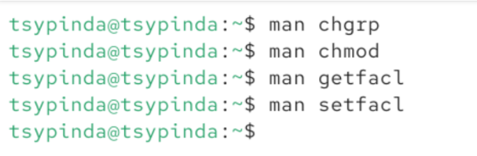

Рисунок 1: Полный перечень всех введенных man команд

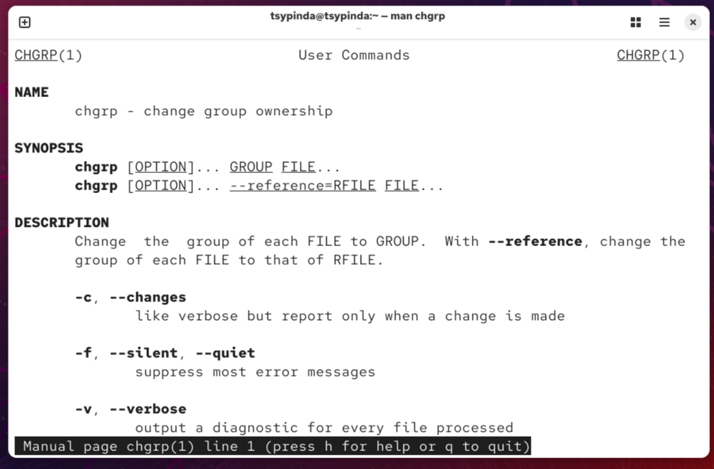

Рисунок 2: man chgrp

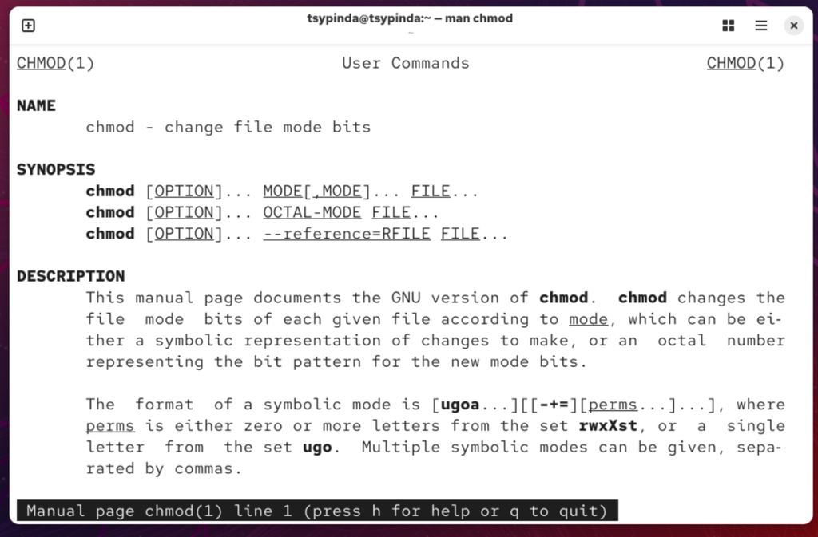

Рисунок 3: man chmod

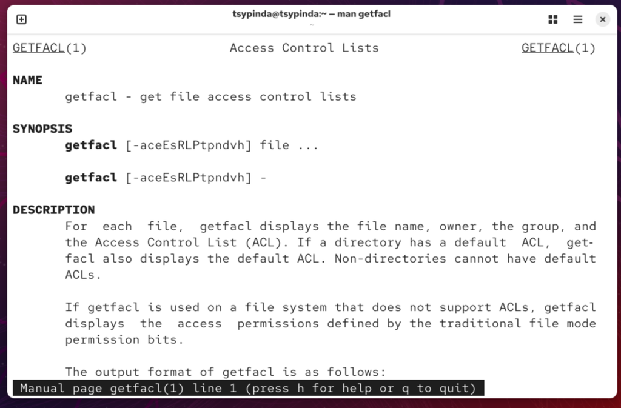

Рисунок 4: man getfacl

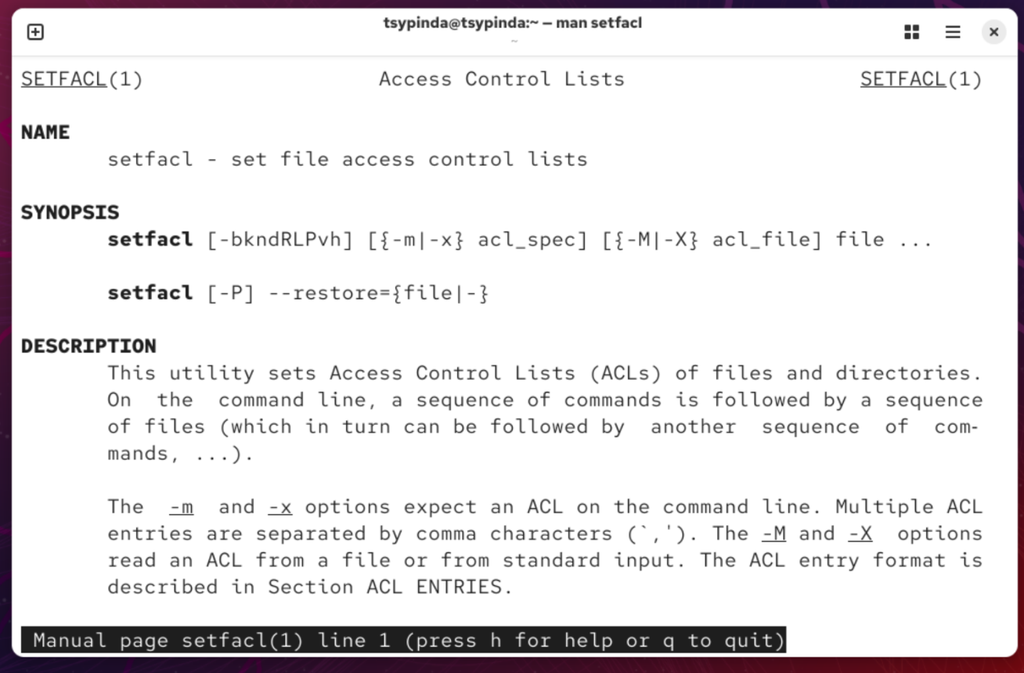

Рисунок 5: man setfacl

## Задание 2

Переходим в рут и создаем каталоги /data/main и /data/third (рис.6)

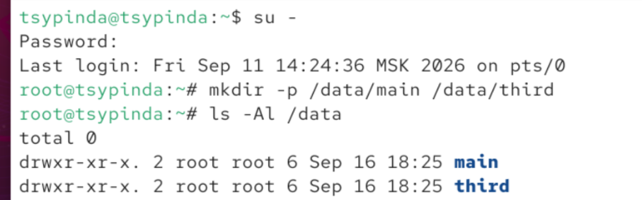

Рисунок 6: root, создание /data/main и /data/third

Меняем группу директорий /data/main на main и /data/third на third (рис.7)

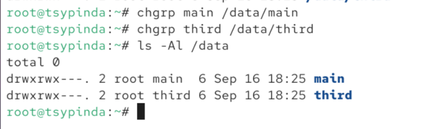

Переходим в bob (рис.8)

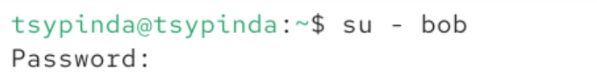

Рисунок 8: su - bob

Пробуем перейти в каталог /data/main и создать там файл emptyfile. Файл успешно создается (рис.9)

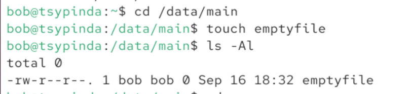

Рисунок 9: В /data/main создаем emptyfile

Аналогичное пробуем провернуть в директории /data/third, однако получаем отказ “Permission denied” (Отказ в доступе) (рис.10)

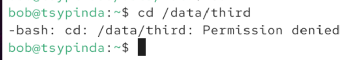

Рисунок 10: Пытаемся перейти в /data/third - Permission denied

## Задание 3

Переходим в alice, затем в каталог /data/main и создаем файлы alice1 и alice2

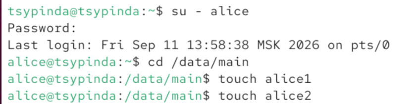

Рисунок 11: Создаем data/main/alice1 и data/main/alice2

Переходим в терминал пользователя bob, переходим в /data/main и просматриваем файлы в директории (рис.12)

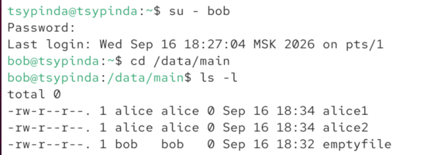

Рисунок 12: Просмотр файлов в /data/main

От пользователя bob пробуем удалить файлы alice1 и alice2. У нас это получается (рис.13)

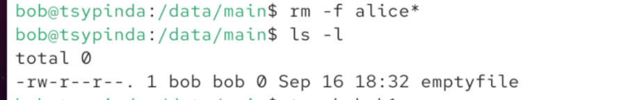

Рисунок 13: Удаляем alice1 и alice2

Создаем файлы bob1 и bob2 (рис.14)

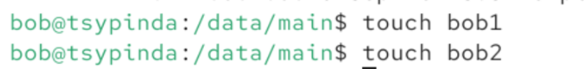

Рисунок 14: touch bob1, touch bob2

Заходим в root и вводим команду chmod g+s,o+t /data/main. Эта команда изменяет права доступа к директории /data/main, устанавливая для неё два специальных флага: SGID (g+s) и Sticky bit (o+t) (рис.15)

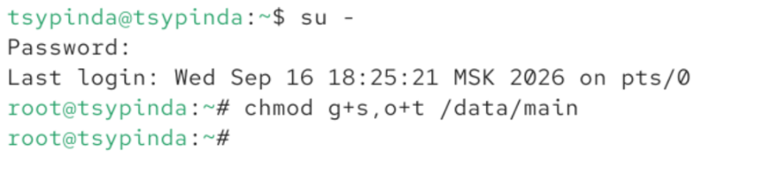

Рисунок 15: chmod g+s,o+t /data/main

В терминале пользователя alice создаем alice3, alice4 и смотрим группу файлов. Группа изменилась на main благодаря предыдущему шагу (рис.16)

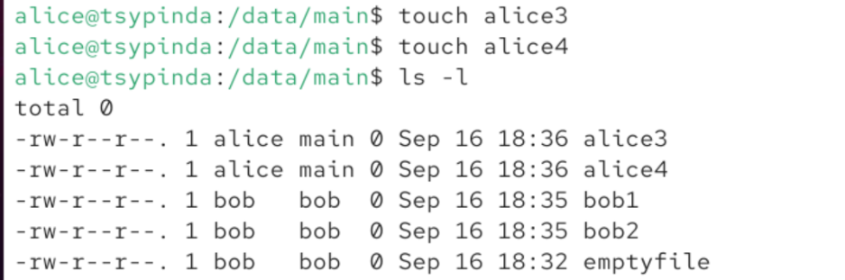

Рисунок 16: Создаем alice3 и alice4. Проверяем группу main

Пробуем удалить файлы bob1 и bob2, однако у нас это не получается - недостаточно прав (рис.17).

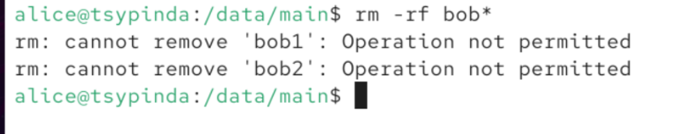

Рисунок 17: Пробуем удалить bob1, bob2 из терминала alice

## Задание 4

Заходим в терминал с root (рис.18)

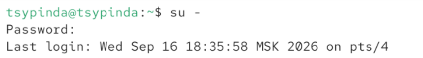

Рисунок 18: Заходим в root терминал

Устанавливаем права на чтение и выполнение в каталоге /data/main для группы third и права на чтение и выполнение для группы main в каталоге /data/third (рис.19)

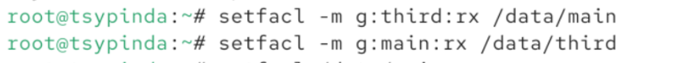

Рисунок 19: Права на чтение и исполнение main, third

Убеждаемся в правильности установки разрешений с помощью getfacl (рис.20, рис.21)

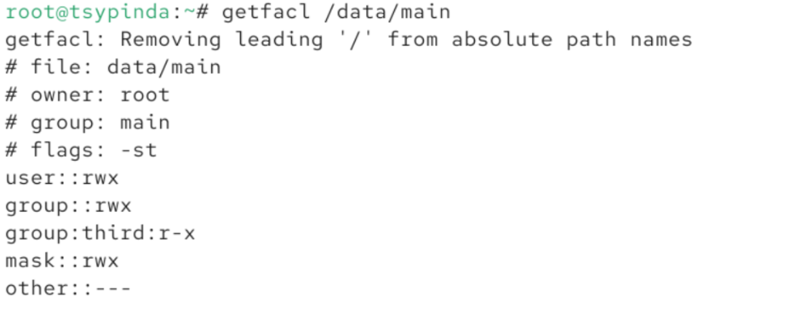

Рисунок 20: getfacl для main

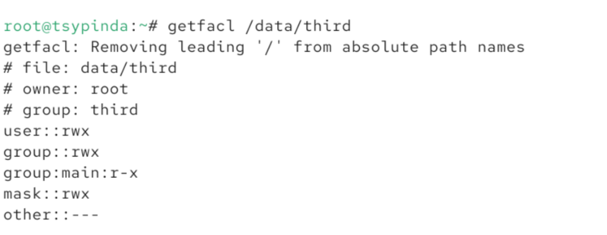

Рисунок 21: getfacl для third

Создаем файл newfile1 в /data/main и смотрим его права (рис.22)

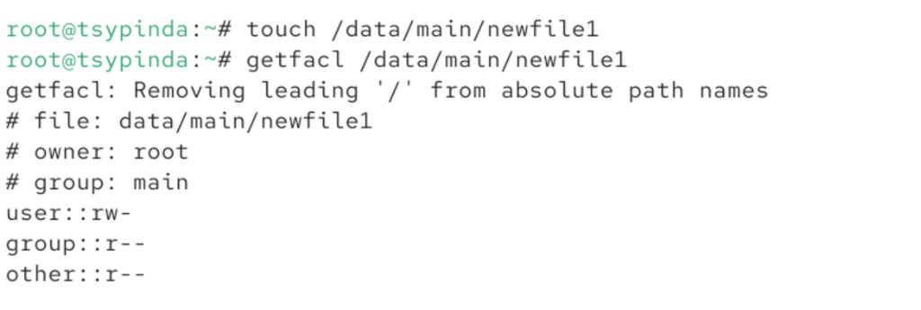

Рисунок 22: Создание newfile1 и просмотр прав в /data/main

Проводим аналогичное в /data/third (рис.23)

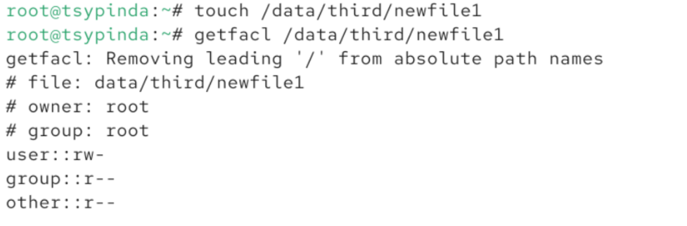

Рисунок 23: Создание newfile1 и просмотр прав в /data/third

Устанавливаем ACL по умолчанию для каталогов /data/main и /data/third. Создаем newfile2 в /data/main и убеждаемся в правильности правах (рис.24)

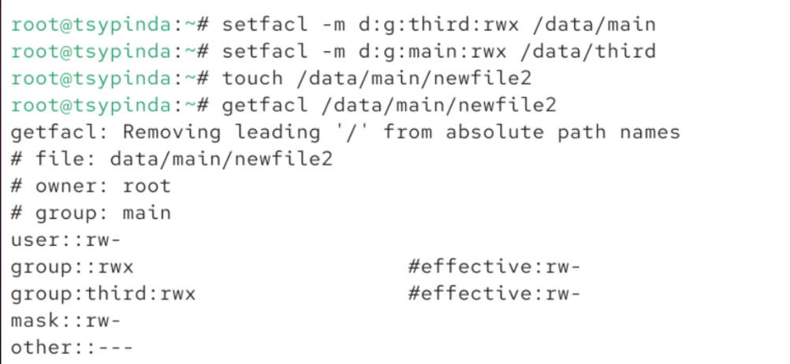

Рисунок 24: Создание /data/main/newfile2 и проверка его прав

Аналогично создаем /data/third/newfile2 и проверяем его права (рис.25)

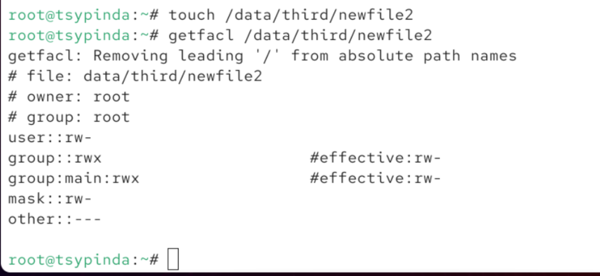

Рисунок 25: Создание /data/third/newfile2 и проверка его прав

Переходим в пользователя carol и пробуем удалить newfile1 и newfile2. У нас не получается - недостаточно прав. Пробуем записать в файл “Hello, world”. В первый файл у нас не получается сделать запись, во вторую - получается. Это происходит потому, что newfile1 был создан раньше объявления новых правил (рис.26)

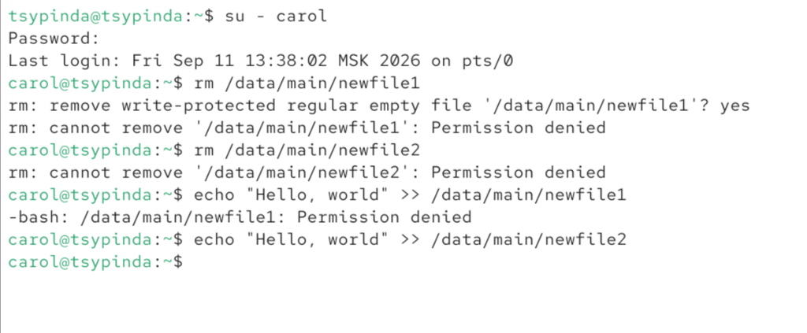

Рисунок 26: Пробуем удалить newfile1, newfile2. Пробуем записать в файлы “Hello, world”

# Выводы

Я получил представление о работе с учётными записями пользователей и группами пользователей в операционной системе типа Linux.